# Zadanie 2: Porovnanie intervalov spolahlivosti spotreby staveniska

Jozef Barčák

2026-10-07

Subor Kontajner_spotreba.xlsx obsahuje hodinove merania spotreby elektrickej energie (kWh) kontajnerov na stavenisku. Cielom je zostavit intervaly spolahlivosti (IS) pre priemernu spotrebu a porovnat ich podla hodiny, dna v tyzdni, typu dna a mesiaca.

```r
library(readxl)
library(Rmisc)
library(ggplot2)
```

# 1. Import a uprava dat

```r
data <- read_xlsx("Kontajner_spotreba.xlsx")
str(data)
```

```
## tibble [8,904 × 3] (S3: tbl_df/tbl/data.frame)
##  $ Datum   : POSIXct[1:8904], format: "2022-12-01" "2022-12-01" ...
##  $ Cas     : POSIXct[1:8904], format: "1899-12-31 00:00:00" "1899-12-31 01:00:00" ...
##  $ Spotreba: num [1:8904] 7984 7966 8062 8057 8066 ...
```

```r
head(data)
```

```
## # A tibble: 6 × 3
##   Datum               Cas                 Spotreba
##   <dttm>              <dttm>                 <dbl>
## 1 2022-12-01 00:00:00 1899-12-31 00:00:00    7984.
## 2 2022-12-01 00:00:00 1899-12-31 01:00:00    7966.
## 3 2022-12-01 00:00:00 1899-12-31 02:00:00    8062.
## 4 2022-12-01 00:00:00 1899-12-31 03:00:00    8057.
## 5 2022-12-01 00:00:00 1899-12-31 04:00:00    8066.
## 6 2022-12-01 00:00:00 1899-12-31 05:00:00    7991.
```

Stlpec Cas sa nacital zle - Excel uklada cas ako datum s casom, preto je pri kazdej hodine vymysleny datum 1899-12-31. Zo stlpca Cas nechame len hodinu a minuty, zo stlpca Datum len datum.

```r
data$hodina <- as.numeric(format(data$Cas, "%H"))
data$Cas <- format(data$Cas, "%H:%M")
data$Datum <- as.Date(data$Datum)
sum(is.na(data))
```

```
## [1] 0
```

```r
head(data)
```

```
## # A tibble: 6 × 4
##   Datum      Cas   Spotreba hodina
##   <date>     <chr>    <dbl>  <dbl>
## 1 2022-12-01 00:00    7984.      0
## 2 2022-12-01 01:00    7966.      1
## 3 2022-12-01 02:00    8062.      2
## 4 2022-12-01 03:00    8057.      3
## 5 2022-12-01 04:00    8066.      4
## 6 2022-12-01 05:00    7991.      5
```

```r
range(data$Datum)
```

```
## [1] "2022-12-01" "2023-12-06"
```

Data su od 1.12.2022 do 6.12.2023, spolu 8904 hodinovych merani, ziadne hodnoty nechybaju.

# 2. Priprava premennych

Den v tyzdni ako cislo (1 = pondelok, …, 7 = nedela), typ dna (pracovny / vikend) a mesiac spolu s rokom, lebo december je v datach dvakrat (2022 aj 2023).

```r
data$den <- as.numeric(format(data$Datum, "%u"))
data$typ_dna <- ifelse(data$den >= 6, "vikend", "pracovny")
data$mesiac <- format(data$Datum, "%Y-%m")
head(data)
```

```
## # A tibble: 6 × 7
##   Datum      Cas   Spotreba hodina   den typ_dna  mesiac
##   <date>     <chr>    <dbl>  <dbl> <dbl> <chr>    <chr>
## 1 2022-12-01 00:00    7984.      0     4 pracovny 2022-12
## 2 2022-12-01 01:00    7966.      1     4 pracovny 2022-12
## 3 2022-12-01 02:00    8062.      2     4 pracovny 2022-12
## 4 2022-12-01 03:00    8057.      3     4 pracovny 2022-12
## 5 2022-12-01 04:00    8066.      4     4 pracovny 2022-12
## 6 2022-12-01 05:00    7991.      5     4 pracovny 2022-12
```

```r
table(data$hodina)
```

```
##
##   0   1   2   3   4   5   6   7   8   9  10  11  12  13  14  15  16  17  18  19
## 371 370 372 371 371 371 371 371 371 371 371 371 371 371 371 371 371 371 371 371
##  20  21  22  23
## 371 371 371 371
```

```r
table(data$den)
```

```
##
##    1    2    3    4    5    6    7
## 1272 1272 1272 1272 1272 1272 1272
```

```r
table(data$typ_dna)
```

```
##
## pracovny   vikend
##     6360     2544
```

```r
table(data$mesiac)
```

```
##
## 2022-12 2023-01 2023-02 2023-03 2023-04 2023-05 2023-06 2023-07 2023-08 2023-09
##     744     744     672     744     720     744     720     744     744     720
## 2023-10 2023-11 2023-12
##     744     720     144
```

Kazda hodina ma 371 merani, len hodina 1 ma 370 a hodina 2 ma 372 - je to den zmeny casu 29.10.2023. December 2023 ma len 144 merani (6 dni).

# 3. Spotreba ako celok

```r
summary(data$Spotreba)
```

```
##    Min. 1st Qu.  Median    Mean 3rd Qu.    Max.
##   248.1  1358.0  3102.6  4073.1  5760.3 27751.6
```

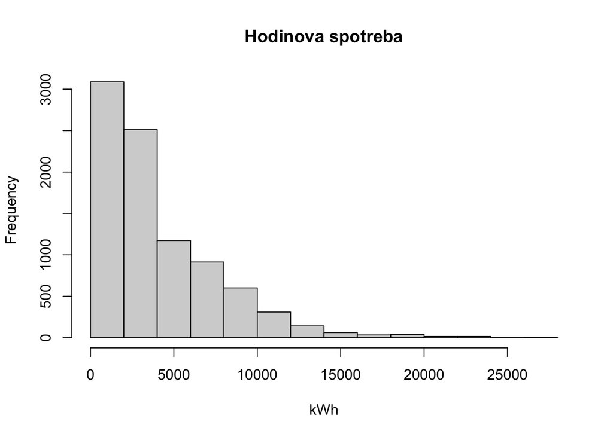

```r
hist(data$Spotreba, main = "Hodinova spotreba", xlab = "kWh")
```

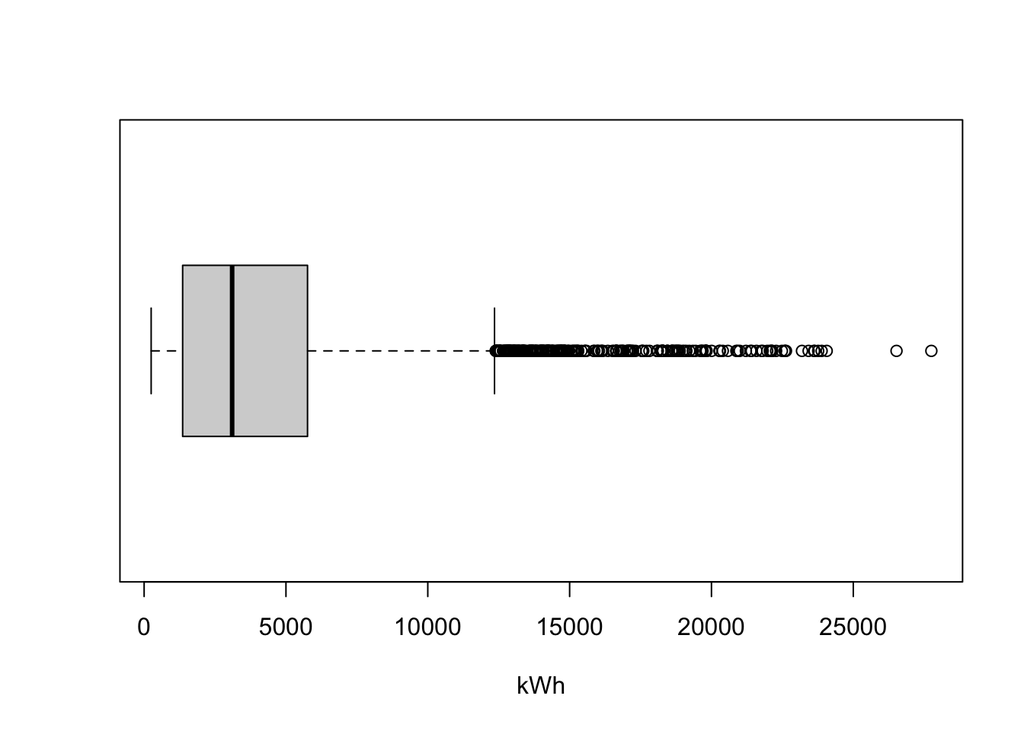

```r
boxplot(data$Spotreba, horizontal = T, xlab = "kWh")
```

Spotreba nema normalne rozdelenie, je silno zosikmena doprava (median 3103, priemer 4073 kWh). Test shapiro.test sa neda pouzit, lebo berie najviac 5000 hodnot. Kazda skupina, pre ktoru budeme ratat IS, ma ale stovky merani, takze IS pre priemer cez t.test pouzit mozeme.

95% IS pre priemernu hodinovu spotrebu, $\sigma$ nepozname:

```r
t.test(data$Spotreba)$conf.int
```

```
## [1] 3998.835 4147.383
## attr(,"conf.level")
## [1] 0.95
```

```r
CI(data$Spotreba)
```

```
##    upper     mean    lower
## 4147.383 4073.109 3998.835
```

Priemerna hodinova spotreba je s 95% spolahlivostou medzi 3999 a 4147 kWh.

# 4. IS podla hodiny dna

```r
CI_hodina <- group.CI(Spotreba ~ hodina, data = data)
CI_hodina
```

```
##    hodina Spotreba.upper Spotreba.mean Spotreba.lower
## 1       0       3678.081      3376.378       3074.675
## 2       1       3749.994      3444.951       3139.909
## 3       2       3868.249      3560.624       3252.999
## 4       3       3860.352      3552.068       3243.784
## 5       4       3856.696      3548.115       3239.534
## 6       5       3855.831      3548.574       3241.317
## 7       6       4622.080      4263.230       3904.380
## 8       7       6124.829      5666.552       5208.274
## 9       8       5907.341      5464.751       5022.160
## 10      9       5682.828      5259.830       4836.833
## 11     10       5546.991      5138.882       4730.773
## 12     11       5890.534      5445.950       5001.367
## 13     12       5158.336      4751.163       4343.990
## 14     13       5040.692      4632.213       4223.734
## 15     14       4880.277      4479.893       4079.510
## 16     15       4791.201      4395.020       3998.839
## 17     16       4311.023      3966.351       3621.679
## 18     17       3803.245      3502.543       3201.841
## 19     18       3521.763      3233.090       2944.416
## 20     19       3533.729      3239.705       2945.682
## 21     20       3561.212      3264.071       2966.931
## 22     21       3598.385      3295.526       2992.666
## 23     22       3639.259      3334.023       3028.788
## 24     23       3700.375      3390.803       3081.232
```

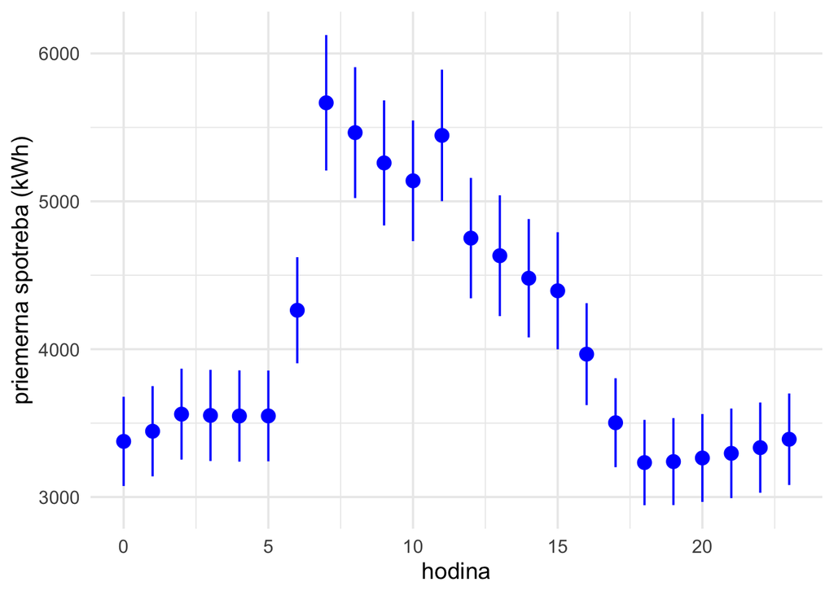

```r
ggplot(CI_hodina, aes(x = hodina, y = Spotreba.mean,
                      ymin = Spotreba.lower, ymax = Spotreba.upper)) +
  geom_pointrange(color = "blue") +
  labs(y = "priemerna spotreba (kWh)") +
  theme_minimal(base_size = 14)
```

V noci (hodiny 18 az 5) je priemer okolo 3200 az 3600 kWh a intervaly sa navzajom prekryvaju, spotreba je teda v noci rovnaka. O 6:00 zacne rast a medzi 7:00 a 11:00 je najvyssia (priemer 5100 az 5700 kWh). IS pre 7:00 (5208 az 6125) sa s nocnymi intervalmi vobec neprekryva, rozdiel medzi pracovnou zmenou a nocou je teda preukazny. Po 12:00 spotreba postupne klesa a od 17:00 je naspat na nocnej urovni.

# 5. IS podla dna v tyzdni

```r
CI_den <- group.CI(Spotreba ~ den, data = data)
CI_den
```

```
##   den Spotreba.upper Spotreba.mean Spotreba.lower
## 1   1       4676.497      4461.062       4245.627
## 2   2       4651.604      4443.300       4234.995
## 3   3       4706.970      4506.795       4306.621
## 4   4       4508.430      4308.345       4108.260
## 5   5       4205.269      4009.141       3813.013
## 6   6       3672.308      3491.645       3310.982
## 7   7       3450.950      3291.476       3132.002
```

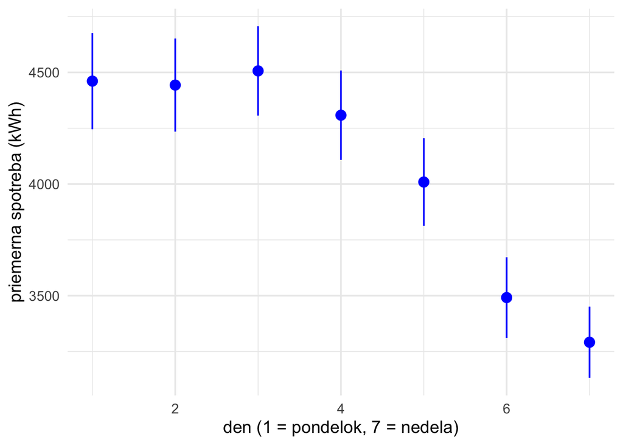

```r
ggplot(CI_den, aes(x = den, y = Spotreba.mean,
                   ymin = Spotreba.lower, ymax = Spotreba.upper)) +
  geom_pointrange(color = "blue") +
  labs(x = "den (1 = pondelok, 7 = nedela)", y = "priemerna spotreba (kWh)") +
  theme_minimal(base_size = 14)
```

Pondelok az stvrtok maju priemer 4300 az 4500 kWh a ich intervaly sa prekryvaju, medzi tymito dnami rozdiel nevidime. Piatok je nizsie (4009), jeho IS (3813 az 4205) sa prekryva uz len so stvrtkom. Sobota (3492) a nedela (3291) su najnizsie a ich intervaly lezia cele pod intervalmi pracovnych dni.

# 6. IS pre pracovne dni a vikendy

```r
CI_typ <- group.CI(Spotreba ~ typ_dna, data = data)
CI_typ
```

```
##    typ_dna Spotreba.upper Spotreba.mean Spotreba.lower
## 1 pracovny       4437.034      4345.729       4254.423
## 2   vikend       3512.032      3391.561       3271.089
```

```r
tapply(data$Spotreba, data$typ_dna, t.test)
```

```
## $pracovny
##
##  One Sample t-test
##
## data:  X[[i]]
## t = 93.303, df = 6359, p-value < 2.2e-16
## alternative hypothesis: true mean is not equal to 0
## 95 percent confidence interval:
##  4254.423 4437.034
## sample estimates:
## mean of x
##  4345.729
##
##
## $vikend
##
##  One Sample t-test
##
## data:  X[[i]]
## t = 55.204, df = 2543, p-value < 2.2e-16
## alternative hypothesis: true mean is not equal to 0
## 95 percent confidence interval:
##  3271.089 3512.032
## sample estimates:
## mean of x
##  3391.561
```

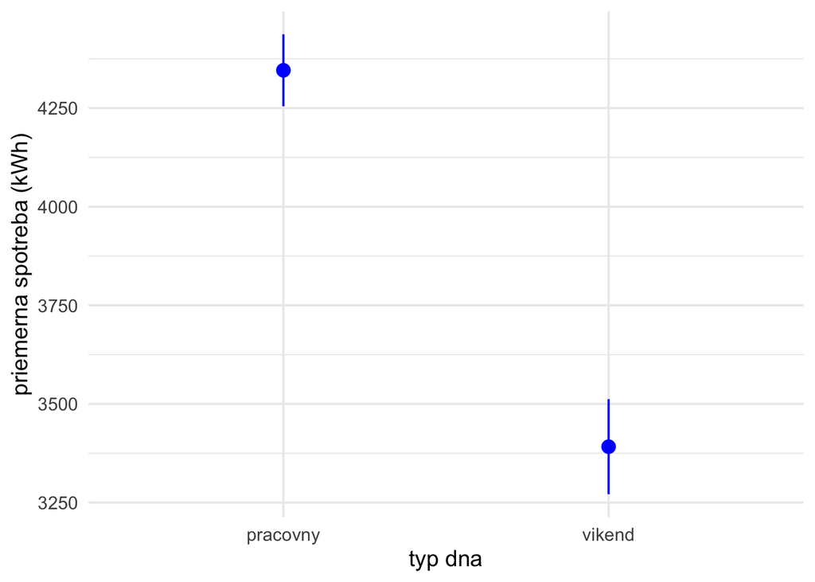

```r
ggplot(CI_typ, aes(x = typ_dna, y = Spotreba.mean,
                   ymin = Spotreba.lower, ymax = Spotreba.upper)) +
  geom_pointrange(color = "blue") +
  labs(x = "typ dna", y = "priemerna spotreba (kWh)") +
  theme_minimal(base_size = 14)
```

Pracovny den: 95% IS je 4254 az 4437 kWh. Vikend: 3271 az 3512 kWh. Intervaly sa neprekryvaju a je medzi nimi velka medzera, cez vikend je spotreba preukazne nizsia, v priemere asi o 950 kWh za hodinu. Na nulu ale neklesne - cast spotreby bezi stale, aj ked sa na stavbe nepracuje.

# 7. IS podla mesiaca

```r
CI_mesiac <- group.CI(Spotreba ~ mesiac, data = data)
CI_mesiac
```

```
##     mesiac Spotreba.upper Spotreba.mean Spotreba.lower
## 1  2022-12       7008.153      6775.009       6541.864
## 2  2023-01       8711.022      8443.967       8176.913
## 3  2023-02       7895.547      7515.879       7136.212
## 4  2023-03       6848.434      6605.254       6362.075
## 5  2023-04       3311.567      3226.841       3142.115
## 6  2023-05       2842.826      2754.162       2665.497
## 7  2023-06       1543.983      1475.707       1407.432
## 8  2023-07       1252.327      1183.575       1114.824
## 9  2023-08       1242.991      1178.746       1114.501
## 10 2023-09       1164.991      1112.714       1060.437
## 11 2023-10       3494.355      3327.982       3161.608
## 12 2023-11       5150.945      5021.068       4891.190
## 13 2023-12       6460.880      6209.902       5958.924
```

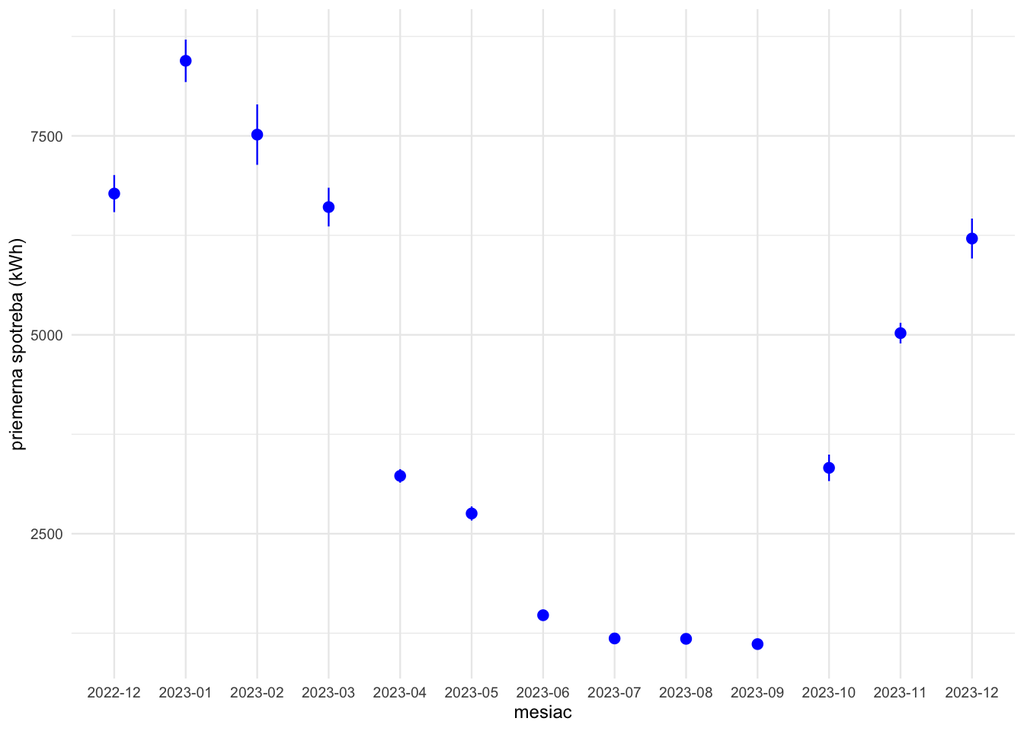

```r
ggplot(CI_mesiac, aes(x = mesiac, y = Spotreba.mean,
                      ymin = Spotreba.lower, ymax = Spotreba.upper)) +
  geom_pointrange(color = "blue") +
  labs(y = "priemerna spotreba (kWh)") +
  theme_minimal(base_size = 9)
```

Toto je najvacsi rozdiel zo vsetkych. V zime je spotreba najvyssia (januar 8444, februar 7516 kWh), v lete najnizsia (jul, august a september okolo 1100 az 1200 kWh), teda asi sedemkrat mensia. Intervaly letnych mesiacov jul, august a september sa prekryvaju, medzi nimi rozdiel nie je. Prekryva sa este marec s decembrom 2022 aj 2023 a april s oktobrom, ostatne mesiace maju intervaly oddelene. Vysoka spotreba v zime ukazuje, ze velku cast energie beru kontajnery na kurenie.

# 8. Zaver

- Priemerna hodinova spotreba staveniska je s 95% spolahlivostou 3999 az 4147 kWh.
- Najviac spotrebu ovplyvnuje mesiac: v zime je priblizne sedemkrat vyssia ako v lete a intervaly zimnych a letnych mesiacov su daleko od seba.
- Cez den je spotreba najvyssia medzi 7:00 a 11:00, v noci je nizsia a rovnomerna.
- Cez vikend je spotreba preukazne nizsia ako v pracovny den, intervaly sa neprekryvaju. Pondelok az stvrtok sa medzi sebou nelisia, piatok je o nieco nizsie.
- Ked sa dva intervaly neprekryvaju, priemery skupin sa preukazne lisia. Ked sa prekryvaju, rozdiel z tychto dat nevieme potvrdit.